# Risk Factor Analysis

## Outcome Variable

**Outcome Variable:** ever_swasted

## Predictor Variables

**Intervention Variable:** nrooms

**Adjustment Set:**

- arm
- sex
- W_mage
- meducyrs
- feducyrs
- hhwealth_quart
- hfoodsec
- W_mhtcm
- W_mwtkg
- W_mbmi
- W_nchldlt5
- W_parity
- impfloor
- impsan
- safeh20
- delta_W_mage
- delta_meducyrs
- delta_feducyrs
- delta_hhwealth_quart
- delta_hfoodsec
- delta_W_mhtcm
- delta_W_mwtkg
- delta_W_mbmi
- delta_W_nchldlt5
- delta_W_parity
- delta_impfloor
- delta_impsan
- delta_safeh20

## Stratifying Variables

The analysis was stratified on these variable(s):

- agecat
- studyid
- country

## Data Summary

| agecat | studyid | country | nrooms | ever_swasted | n_cell | n |
| --- | --- | --- | --- | --- | --- | --- |
| 0-24 months | CMC-V-BCS-2002 | INDIA | 4+ | 0 | 11 | 373 |
| 0-24 months | CMC-V-BCS-2002 | INDIA | 4+ | 1 | 3 | 373 |
| 0-24 months | CMC-V-BCS-2002 | INDIA | 1 | 0 | 145 | 373 |
| 0-24 months | CMC-V-BCS-2002 | INDIA | 1 | 1 | 57 | 373 |
| 0-24 months | CMC-V-BCS-2002 | INDIA | 2 | 0 | 83 | 373 |
| 0-24 months | CMC-V-BCS-2002 | INDIA | 2 | 1 | 23 | 373 |
| 0-24 months | CMC-V-BCS-2002 | INDIA | 3 | 0 | 42 | 373 |
| 0-24 months | CMC-V-BCS-2002 | INDIA | 3 | 1 | 9 | 373 |
| 0-24 months | COHORTS | INDIA | 4+ | 0 | 100 | 5366 |
| 0-24 months | COHORTS | INDIA | 4+ | 1 | 6 | 5366 |
| 0-24 months | COHORTS | INDIA | 1 | 0 | 3106 | 5366 |
| 0-24 months | COHORTS | INDIA | 1 | 1 | 405 | 5366 |
| 0-24 months | COHORTS | INDIA | 2 | 0 | 1423 | 5366 |
| 0-24 months | COHORTS | INDIA | 2 | 1 | 131 | 5366 |
| 0-24 months | COHORTS | INDIA | 3 | 0 | 184 | 5366 |
| 0-24 months | COHORTS | INDIA | 3 | 1 | 11 | 5366 |
| 0-24 months | CONTENT | PERU | 4+ | 0 | 77 | 215 |
| 0-24 months | CONTENT | PERU | 4+ | 1 | 1 | 215 |
| 0-24 months | CONTENT | PERU | 1 | 0 | 44 | 215 |
| 0-24 months | CONTENT | PERU | 1 | 1 | 0 | 215 |
| 0-24 months | CONTENT | PERU | 2 | 0 | 54 | 215 |
| 0-24 months | CONTENT | PERU | 2 | 1 | 0 | 215 |
| 0-24 months | CONTENT | PERU | 3 | 0 | 39 | 215 |
| 0-24 months | CONTENT | PERU | 3 | 1 | 0 | 215 |
| 0-24 months | GMS-Nepal | NEPAL | 4+ | 0 | 234 | 686 |
| 0-24 months | GMS-Nepal | NEPAL | 4+ | 1 | 80 | 686 |
| 0-24 months | GMS-Nepal | NEPAL | 1 | 0 | 38 | 686 |
| 0-24 months | GMS-Nepal | NEPAL | 1 | 1 | 11 | 686 |
| 0-24 months | GMS-Nepal | NEPAL | 2 | 0 | 104 | 686 |
| 0-24 months | GMS-Nepal | NEPAL | 2 | 1 | 39 | 686 |

[output cut: 98 more lines]

The following strata were considered:

- agecat: 0-24 months, studyid: CMC-V-BCS-2002, country: INDIA
- agecat: 0-24 months, studyid: COHORTS, country: INDIA
- agecat: 0-24 months, studyid: CONTENT, country: PERU
- agecat: 0-24 months, studyid: GMS-Nepal, country: NEPAL
- agecat: 0-24 months, studyid: IRC, country: INDIA
- agecat: 0-24 months, studyid: JiVitA-3, country: BANGLADESH
- agecat: 0-24 months, studyid: JiVitA-4, country: BANGLADESH
- agecat: 0-24 months, studyid: MAL-ED, country: BANGLADESH
- agecat: 0-24 months, studyid: MAL-ED, country: BRAZIL
- agecat: 0-24 months, studyid: MAL-ED, country: INDIA
- agecat: 0-24 months, studyid: MAL-ED, country: NEPAL
- agecat: 0-24 months, studyid: MAL-ED, country: PERU
- agecat: 0-24 months, studyid: MAL-ED, country: SOUTH AFRICA
- agecat: 0-24 months, studyid: MAL-ED, country: TANZANIA, UNITED REPUBLIC OF
- agecat: 0-24 months, studyid: NIH-Crypto, country: BANGLADESH
- agecat: 0-24 months, studyid: PROVIDE, country: BANGLADESH

### Dropped Strata

Some strata were dropped due to rare outcomes:

- agecat: 0-24 months, studyid: CMC-V-BCS-2002, country: INDIA
- agecat: 0-24 months, studyid: CONTENT, country: PERU
- agecat: 0-24 months, studyid: MAL-ED, country: BANGLADESH
- agecat: 0-24 months, studyid: MAL-ED, country: BRAZIL
- agecat: 0-24 months, studyid: MAL-ED, country: INDIA
- agecat: 0-24 months, studyid: MAL-ED, country: NEPAL
- agecat: 0-24 months, studyid: MAL-ED, country: PERU
- agecat: 0-24 months, studyid: MAL-ED, country: SOUTH AFRICA
- agecat: 0-24 months, studyid: MAL-ED, country: TANZANIA, UNITED REPUBLIC OF
- agecat: 0-24 months, studyid: PROVIDE, country: BANGLADESH

## Methods Detail

We're interested in the causal parameters $E[Y_a]$ for all values of $a \in \mathcal{A}$. These parameters represent the mean outcome if, possibly contrary to fact, we intervened to set all units to have $A=a$. Under the randomization and positivity assumptions, these are identified by the statistical parameters $\psi_a=E_W[E_{Y|A,W}(Y|A=a,W)]$. In addition, we're interested in the mean of $Y$, $E[Y]$ under no intervention (the observed mean). We will estimate these parameters by using SuperLearner to fit the relevant likelihood factors -- $E_{Y|A,W}(Y|A=a,W)$ and $p(A=a|W)$, and then updating our likelihood fit using a joint TMLE.

For unadjusted analyses ($W=\{\}$), initial likelihoods were estimated using Lrnr_glm to estimate the simple $E(Y|A)$ and Lrnr_mean to estimate $p(A)$. For adjusted analyses, a small library containing Lrnr_glmnet, Lrnr_xgboost, and Lrnr_mean was used.

Having estimated these parameters, we will then use the delta method to estimate relative risks and attributable risks relative to a prespecified baseline level of $A$.

# Results Detail

## Results Plots

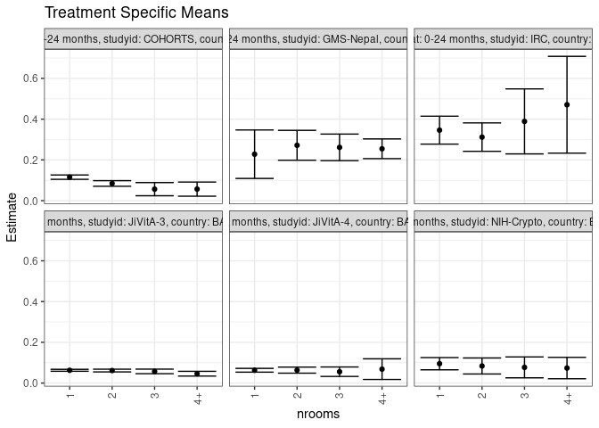

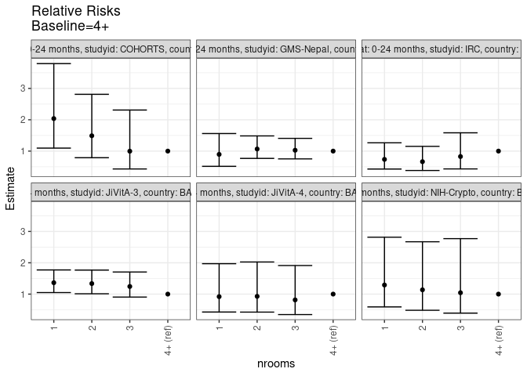

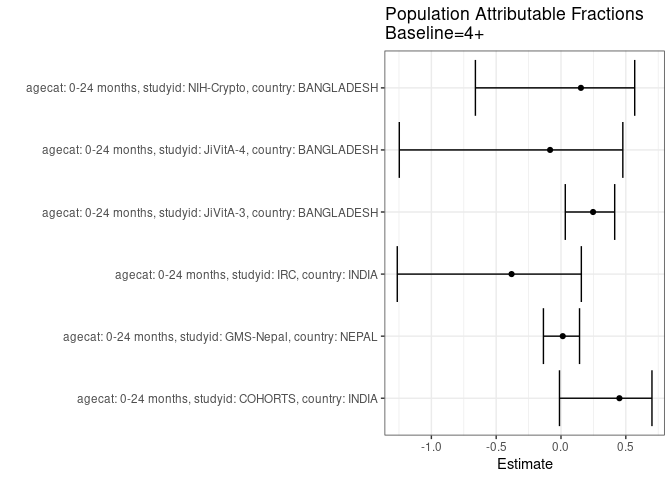

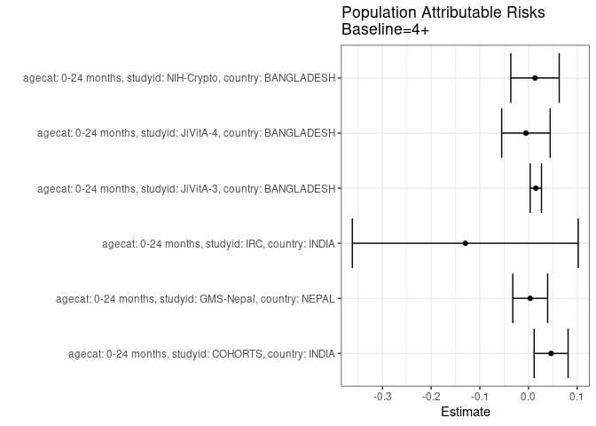

## Results Table

### Parameter: TSM

| agecat | studyid | country | intervention_level | baseline_level | estimate | ci_lower | ci_upper |
| --- | --- | --- | --- | --- | --- | --- | --- |
| 0-24 months | COHORTS | INDIA | 4+ | NA | 0.0566038 | 0.0218405 | 0.0913670 |
| 0-24 months | COHORTS | INDIA | 1 | NA | 0.1153518 | 0.1047843 | 0.1259192 |
| 0-24 months | COHORTS | INDIA | 2 | NA | 0.0842986 | 0.0704836 | 0.0981136 |
| 0-24 months | COHORTS | INDIA | 3 | NA | 0.0564103 | 0.0240254 | 0.0887951 |
| 0-24 months | GMS-Nepal | NEPAL | 4+ | NA | 0.2545299 | 0.2061069 | 0.3029529 |
| 0-24 months | GMS-Nepal | NEPAL | 1 | NA | 0.2279077 | 0.1089557 | 0.3468597 |
| 0-24 months | GMS-Nepal | NEPAL | 2 | NA | 0.2716213 | 0.1983367 | 0.3449060 |
| 0-24 months | GMS-Nepal | NEPAL | 3 | NA | 0.2614960 | 0.1963748 | 0.3266172 |
| 0-24 months | IRC | INDIA | 4+ | NA | 0.4705882 | 0.2330280 | 0.7081485 |
| 0-24 months | IRC | INDIA | 1 | NA | 0.3459459 | 0.2773172 | 0.4145747 |
| 0-24 months | IRC | INDIA | 2 | NA | 0.3117647 | 0.2420477 | 0.3814817 |
| 0-24 months | IRC | INDIA | 3 | NA | 0.3888889 | 0.2294469 | 0.5483308 |
| 0-24 months | JiVitA-3 | BANGLADESH | 4+ | NA | 0.0459494 | 0.0342629 | 0.0576359 |
| 0-24 months | JiVitA-3 | BANGLADESH | 1 | NA | 0.0626469 | 0.0578696 | 0.0674241 |
| 0-24 months | JiVitA-3 | BANGLADESH | 2 | NA | 0.0614046 | 0.0546774 | 0.0681318 |
| 0-24 months | JiVitA-3 | BANGLADESH | 3 | NA | 0.0571240 | 0.0459067 | 0.0683413 |
| 0-24 months | JiVitA-4 | BANGLADESH | 4+ | NA | 0.0683197 | 0.0176279 | 0.1190115 |
| 0-24 months | JiVitA-4 | BANGLADESH | 1 | NA | 0.0627874 | 0.0534784 | 0.0720965 |
| 0-24 months | JiVitA-4 | BANGLADESH | 2 | NA | 0.0634457 | 0.0485086 | 0.0783827 |
| 0-24 months | JiVitA-4 | BANGLADESH | 3 | NA | 0.0556617 | 0.0324846 | 0.0788389 |
| 0-24 months | NIH-Crypto | BANGLADESH | 4+ | NA | 0.0736842 | 0.0211140 | 0.1262544 |
| 0-24 months | NIH-Crypto | BANGLADESH | 1 | NA | 0.0951087 | 0.0651157 | 0.1251016 |
| 0-24 months | NIH-Crypto | BANGLADESH | 2 | NA | 0.0837696 | 0.0444541 | 0.1230851 |
| 0-24 months | NIH-Crypto | BANGLADESH | 3 | NA | 0.0769231 | 0.0256764 | 0.1281697 |

### Parameter: E(Y)

| agecat | studyid | country | intervention_level | baseline_level | estimate | ci_lower | ci_upper |
| --- | --- | --- | --- | --- | --- | --- | --- |
| 0-24 months | COHORTS | INDIA | NA | NA | 0.1030563 | 0.0949208 | 0.1111918 |
| 0-24 months | GMS-Nepal | NEPAL | NA | NA | 0.2580175 | 0.2252514 | 0.2907836 |
| 0-24 months | IRC | INDIA | NA | NA | 0.3406863 | 0.2946421 | 0.3867304 |
| 0-24 months | JiVitA-3 | BANGLADESH | NA | NA | 0.0610562 | 0.0575753 | 0.0645372 |
| 0-24 months | JiVitA-4 | BANGLADESH | NA | NA | 0.0630182 | 0.0560941 | 0.0699424 |
| 0-24 months | NIH-Crypto | BANGLADESH | NA | NA | 0.0870712 | 0.0669870 | 0.1071555 |

### Parameter: RR

| agecat | studyid | country | intervention_level | baseline_level | estimate | ci_lower | ci_upper |
| --- | --- | --- | --- | --- | --- | --- | --- |
| 0-24 months | COHORTS | INDIA | 4+ | 4+ | 1.0000000 | 1.0000000 | 1.000000 |
| 0-24 months | COHORTS | INDIA | 1 | 4+ | 2.0378809 | 1.0952301 | 3.791860 |
| 0-24 months | COHORTS | INDIA | 2 | 4+ | 1.4892750 | 0.7887145 | 2.812095 |
| 0-24 months | COHORTS | INDIA | 3 | 4+ | 0.9965812 | 0.4299360 | 2.310051 |
| 0-24 months | GMS-Nepal | NEPAL | 4+ | 4+ | 1.0000000 | 1.0000000 | 1.000000 |
| 0-24 months | GMS-Nepal | NEPAL | 1 | 4+ | 0.8954065 | 0.5137395 | 1.560621 |
| 0-24 months | GMS-Nepal | NEPAL | 2 | 4+ | 1.0671491 | 0.7670558 | 1.484647 |
| 0-24 months | GMS-Nepal | NEPAL | 3 | 4+ | 1.0273685 | 0.7508642 | 1.405695 |
| 0-24 months | IRC | INDIA | 4+ | 4+ | 1.0000000 | 1.0000000 | 1.000000 |
| 0-24 months | IRC | INDIA | 1 | 4+ | 0.7351351 | 0.4273735 | 1.264523 |
| 0-24 months | IRC | INDIA | 2 | 4+ | 0.6625000 | 0.3814169 | 1.150726 |
| 0-24 months | IRC | INDIA | 3 | 4+ | 0.8263889 | 0.4312690 | 1.583509 |
| 0-24 months | JiVitA-3 | BANGLADESH | 4+ | 4+ | 1.0000000 | 1.0000000 | 1.000000 |
| 0-24 months | JiVitA-3 | BANGLADESH | 1 | 4+ | 1.3633881 | 1.0494662 | 1.771212 |
| 0-24 months | JiVitA-3 | BANGLADESH | 2 | 4+ | 1.3363519 | 1.0110221 | 1.766367 |
| 0-24 months | JiVitA-3 | BANGLADESH | 3 | 4+ | 1.2431946 | 0.9059136 | 1.706049 |
| 0-24 months | JiVitA-4 | BANGLADESH | 4+ | 4+ | 1.0000000 | 1.0000000 | 1.000000 |
| 0-24 months | JiVitA-4 | BANGLADESH | 1 | 4+ | 0.9190240 | 0.4284293 | 1.971399 |
| 0-24 months | JiVitA-4 | BANGLADESH | 2 | 4+ | 0.9286584 | 0.4257703 | 2.025520 |
| 0-24 months | JiVitA-4 | BANGLADESH | 3 | 4+ | 0.8147245 | 0.3471225 | 1.912224 |
| 0-24 months | NIH-Crypto | BANGLADESH | 4+ | 4+ | 1.0000000 | 1.0000000 | 1.000000 |
| 0-24 months | NIH-Crypto | BANGLADESH | 1 | 4+ | 1.2907609 | 0.5916685 | 2.815873 |
| 0-24 months | NIH-Crypto | BANGLADESH | 2 | 4+ | 1.1368736 | 0.4839859 | 2.670494 |
| 0-24 months | NIH-Crypto | BANGLADESH | 3 | 4+ | 1.0439560 | 0.3933243 | 2.770854 |

### Parameter: PAR

| agecat | studyid | country | intervention_level | baseline_level | estimate | ci_lower | ci_upper |
| --- | --- | --- | --- | --- | --- | --- | --- |
| 0-24 months | COHORTS | INDIA | 4+ | NA | 0.0464525 | 0.0116065 | 0.0812985 |
| 0-24 months | GMS-Nepal | NEPAL | 4+ | NA | 0.0034876 | -0.0323273 | 0.0393025 |
| 0-24 months | IRC | INDIA | 4+ | NA | -0.1299020 | -0.3619624 | 0.1021585 |
| 0-24 months | JiVitA-3 | BANGLADESH | 4+ | NA | 0.0151068 | 0.0035183 | 0.0266954 |
| 0-24 months | JiVitA-4 | BANGLADESH | 4+ | NA | -0.0053015 | -0.0551388 | 0.0445359 |
| 0-24 months | NIH-Crypto | BANGLADESH | 4+ | NA | 0.0133870 | -0.0363551 | 0.0631291 |

### Parameter: PAF

| agecat | studyid | country | intervention_level | baseline_level | estimate | ci_lower | ci_upper |
| --- | --- | --- | --- | --- | --- | --- | --- |
| 0-24 months | COHORTS | INDIA | 4+ | NA | 0.4507489 | -0.0116500 | 0.7017973 |
| 0-24 months | GMS-Nepal | NEPAL | 4+ | NA | 0.0135169 | -0.1355342 | 0.1430035 |
| 0-24 months | IRC | INDIA | 4+ | NA | -0.3812950 | -1.2631390 | 0.1569339 |
| 0-24 months | JiVitA-3 | BANGLADESH | 4+ | NA | 0.2474249 | 0.0330862 | 0.4142505 |
| 0-24 months | JiVitA-4 | BANGLADESH | 4+ | NA | -0.0841258 | -1.2475198 | 0.4770552 |
| 0-24 months | NIH-Crypto | BANGLADESH | 4+ | NA | 0.1537480 | -0.6603715 | 0.5686854 |